# Assignment_03

Noah Scheider

October 14, 2022

# 1 Exercise

Slide “Bandwidth > Kernel” above gives a vague statement, that choosing bandwidth h is more important than choosing a proper kernel. See this for yourself using a small simulation study. Specifically:

- use Manual 09 to generate data from the Gaussian mixture $f$
- repeat the following 200 times:
  1. Generate $N = 100$ samples from the Gaussian mixture
  2. Perform density estimation, i.e. obtain $\hat f$ for Gaussian, Epanechnikov, and rectangular kernels as well as bandwidth values $h = 0.1, 0.15, 0.2, 0.25, . . . , 0.9$
  3. Calculate the error measure $||f-\hat f||_{2}$
- report your findings as a single (well commented) figure

**Note**: Please check again Section 5 of the Course Organization for submission instructions.

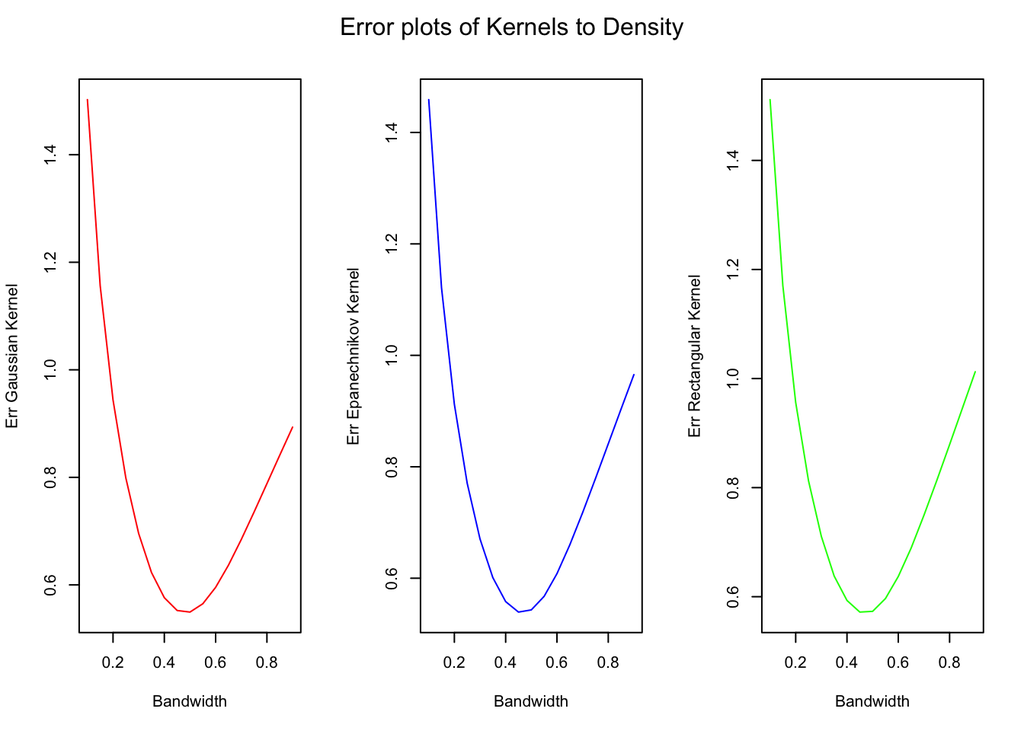

Figure 1.1: The graphs captures the 2-Norm error of different Kernels to its theoretical pdf across a variety of different bandwidths

```r
par(mfrow=c(1,3))
plot(bw, y1, col = "red", type = "l", xlab = "Bandwidth", ylab = "Err Gaussian Kernel")
plot(bw, y2, col = "blue", type = "l", xlab = "Bandwidth", ylab = "Err Epanechnikov Kernel")
plot(bw, y3, col = "green", type = "l", xlab = "Bandwidth", ylab = "Err Rectangular Kernel")
mtext("Error plots of Kernels to Density", side = 3, line = - 2, outer = TRUE)
```

# 2 Conlcusion

Figure 1.1 demonstrates pretty clearly that for each choosen bandwidth different Kernel estimators, given by the Gaussian Kernel, the Epanechnikov and the Rectangular Kernel are nearly identical. Therefore the error given by taking the norm of the difference between the Kernel and its theoretical pdf has a stronger dependence on the bandwidth than the Kernel.